# Supervised Learning - Foundations Project: ReCell

## Problem Statement

### Business Context

Buying and selling used phones and tablets used to be something that happened on a handful of online marketplace sites. But the used and refurbished device market has grown considerably over the past decade, and a new IDC (International Data Corporation) forecast predicts that the used phone market would be worth \$52.7bn by 2023 with a compound annual growth rate (CAGR) of 13.6% from 2018 to 2023. This growth can be attributed to an uptick in demand for used phones and tablets that offer considerable savings compared with new models.

Refurbished and used devices continue to provide cost-effective alternatives to both consumers and businesses that are looking to save money when purchasing one. There are plenty of other benefits associated with the used device market. Used and refurbished devices can be sold with warranties and can also be insured with proof of purchase. Third-party vendors/platforms, such as Verizon, Amazon, etc., provide attractive offers to customers for refurbished devices. Maximizing the longevity of devices through second-hand trade also reduces their environmental impact and helps in recycling and reducing waste. The impact of the COVID-19 outbreak may further boost this segment as consumers cut back on discretionary spending and buy phones and tablets only for immediate needs.

### Objective

The rising potential of this comparatively under-the-radar market fuels the need for an ML-based solution to develop a dynamic pricing strategy for used and refurbished devices. ReCell, a startup aiming to tap the potential in this market, has hired you as a data scientist. They want you to analyze the data provided and build a linear regression model to predict the price of a used phone/tablet and identify factors that significantly influence it.

### Data Description

The data contains the different attributes of used/refurbished phones and tablets. The data was collected in the year 2021. The detailed data dictionary is given below.

- brand_name: Name of manufacturing brand
- os: OS on which the device runs
- screen_size: Size of the screen in cm
- 4g: Whether 4G is available or not
- 5g: Whether 5G is available or not
- main_camera_mp: Resolution of the rear camera in megapixels
- selfie_camera_mp: Resolution of the front camera in megapixels
- int_memory: Amount of internal memory (ROM) in GB
- ram: Amount of RAM in GB
- battery: Energy capacity of the device battery in mAh
- weight: Weight of the device in grams
- release_year: Year when the device model was released
- days_used: Number of days the used/refurbished device has been used
- normalized_new_price: Normalized price of a new device of the same model in euros
- normalized_used_price: Normalized price of the used/refurbished device in euros

## Importing necessary libraries

```python
import pandas as pd
import numpy as np
import matplotlib.pyplot as plt
%matplotlib inline
import seaborn as sns
sns.set()
```

```python
from sklearn.model_selection import train_test_split
import statsmodels.api as sm
import statsmodels.stats.api as sms
from sklearn.metrics import mean_absolute_error, mean_squared_error
from statsmodels.stats.outliers_influence import variance_inflation_factor
```

## Loading the dataset

```python
df = pd.read_csv('used_device_data.csv')
```

## Data Overview

- Observations
- Sanity checks

```python
df
```

|  | brand_name | os | screen_size | 4g | 5g | main_camera_mp | selfie_camera_mp | int_memory | ram | battery | weight | release_year | days_used | normalized_used_price | normalized_new_price |
| --- | --- | --- | --- | --- | --- | --- | --- | --- | --- | --- | --- | --- | --- | --- | --- |
| 0 | Honor | Android | 14.50 | yes | no | 13.0 | 5.0 | 64.0 | 3.0 | 3020.0 | 146.0 | 2020 | 127 | 4.307572 | 4.715100 |
| 1 | Honor | Android | 17.30 | yes | yes | 13.0 | 16.0 | 128.0 | 8.0 | 4300.0 | 213.0 | 2020 | 325 | 5.162097 | 5.519018 |
| 2 | Honor | Android | 16.69 | yes | yes | 13.0 | 8.0 | 128.0 | 8.0 | 4200.0 | 213.0 | 2020 | 162 | 5.111084 | 5.884631 |
| 3 | Honor | Android | 25.50 | yes | yes | 13.0 | 8.0 | 64.0 | 6.0 | 7250.0 | 480.0 | 2020 | 345 | 5.135387 | 5.630961 |
| 4 | Honor | Android | 15.32 | yes | no | 13.0 | 8.0 | 64.0 | 3.0 | 5000.0 | 185.0 | 2020 | 293 | 4.389995 | 4.947837 |
| ... | ... | ... | ... | ... | ... | ... | ... | ... | ... | ... | ... | ... | ... | ... | ... |
| 3449 | Asus | Android | 15.34 | yes | no | NaN | 8.0 | 64.0 | 6.0 | 5000.0 | 190.0 | 2019 | 232 | 4.492337 | 6.483872 |
| 3450 | Asus | Android | 15.24 | yes | no | 13.0 | 8.0 | 128.0 | 8.0 | 4000.0 | 200.0 | 2018 | 541 | 5.037732 | 6.251538 |
| 3451 | Alcatel | Android | 15.80 | yes | no | 13.0 | 5.0 | 32.0 | 3.0 | 4000.0 | 165.0 | 2020 | 201 | 4.357350 | 4.528829 |
| 3452 | Alcatel | Android | 15.80 | yes | no | 13.0 | 5.0 | 32.0 | 2.0 | 4000.0 | 160.0 | 2020 | 149 | 4.349762 | 4.624188 |
| 3453 | Alcatel | Android | 12.83 | yes | no | 13.0 | 5.0 | 16.0 | 2.0 | 4000.0 | 168.0 | 2020 | 176 | 4.132122 | 4.279994 |

3454 rows × 15 columns

```python
df.shape
```

```
(3454, 15)
```

```python
df.describe().T
```

|  | count | mean | std | min | 25% | 50% | 75% | max |
| --- | --- | --- | --- | --- | --- | --- | --- | --- |
| screen_size | 3454.0 | 13.713115 | 3.805280 | 5.080000 | 12.700000 | 12.830000 | 15.340000 | 30.710000 |
| main_camera_mp | 3275.0 | 9.460208 | 4.815461 | 0.080000 | 5.000000 | 8.000000 | 13.000000 | 48.000000 |
| selfie_camera_mp | 3452.0 | 6.554229 | 6.970372 | 0.000000 | 2.000000 | 5.000000 | 8.000000 | 32.000000 |
| int_memory | 3450.0 | 54.573099 | 84.972371 | 0.010000 | 16.000000 | 32.000000 | 64.000000 | 1024.000000 |
| ram | 3450.0 | 4.036122 | 1.365105 | 0.020000 | 4.000000 | 4.000000 | 4.000000 | 12.000000 |
| battery | 3448.0 | 3133.402697 | 1299.682844 | 500.000000 | 2100.000000 | 3000.000000 | 4000.000000 | 9720.000000 |
| weight | 3447.0 | 182.751871 | 88.413228 | 69.000000 | 142.000000 | 160.000000 | 185.000000 | 855.000000 |
| release_year | 3454.0 | 2015.965258 | 2.298455 | 2013.000000 | 2014.000000 | 2015.500000 | 2018.000000 | 2020.000000 |
| days_used | 3454.0 | 674.869716 | 248.580166 | 91.000000 | 533.500000 | 690.500000 | 868.750000 | 1094.000000 |
| normalized_used_price | 3454.0 | 4.364712 | 0.588914 | 1.536867 | 4.033931 | 4.405133 | 4.755700 | 6.619433 |
| normalized_new_price | 3454.0 | 5.233107 | 0.683637 | 2.901422 | 4.790342 | 5.245892 | 5.673718 | 7.847841 |

```python
df.info()
```

```
<class 'pandas.core.frame.DataFrame'>
RangeIndex: 3454 entries, 0 to 3453
Data columns (total 15 columns):
 #   Column                 Non-Null Count  Dtype
---  ------                 --------------  -----
 0   brand_name             3454 non-null   object
 1   os                     3454 non-null   object
 2   screen_size            3454 non-null   float64
 3   4g                     3454 non-null   object
 4   5g                     3454 non-null   object
 5   main_camera_mp         3275 non-null   float64
 6   selfie_camera_mp       3452 non-null   float64
 7   int_memory             3450 non-null   float64
 8   ram                    3450 non-null   float64
 9   battery                3448 non-null   float64
 10  weight                 3447 non-null   float64
 11  release_year           3454 non-null   int64
 12  days_used              3454 non-null   int64
 13  normalized_used_price  3454 non-null   float64
 14  normalized_new_price   3454 non-null   float64
dtypes: float64(9), int64(2), object(4)
memory usage: 404.9+ KB
```

```python
df.isnull().sum()
```

```
brand_name                 0
os                         0
screen_size                0
4g                         0
5g                         0
main_camera_mp           179
selfie_camera_mp           2
int_memory                 4
ram                        4
battery                    6
weight                     7
release_year               0
days_used                  0
normalized_used_price      0
normalized_new_price       0
dtype: int64
```

```python
df.duplicated().sum()
```

```
0
```

```python
df1=df.copy()
```

## Exploratory Data Analysis (EDA)

- EDA is an important part of any project involving data.
- It is important to investigate and understand the data better before building a model with it.
- A few questions have been mentioned below which will help you approach the analysis in the right manner and generate insights from the data.
- A thorough analysis of the data, in addition to the questions mentioned below, should be done.

**Questions**:

1. What does the distribution of normalized used device prices look like?
2. What percentage of the used device market is dominated by Android devices?
3. The amount of RAM is important for the smooth functioning of a device. How does the amount of RAM vary with the brand?
4. A large battery often increases a device's weight, making it feel uncomfortable in the hands. How does the weight vary for phones and tablets offering large batteries (more than 4500 mAh)?
5. Bigger screens are desirable for entertainment purposes as they offer a better viewing experience. How many phones and tablets are available across different brands with a screen size larger than 6 inches?
6. A lot of devices nowadays offer great selfie cameras, allowing us to capture our favorite moments with loved ones. What is the distribution of devices offering greater than 8MP selfie cameras across brands?
7. Which attributes are highly correlated with the normalized price of a used device?

### Distribution of normalized used device prices:

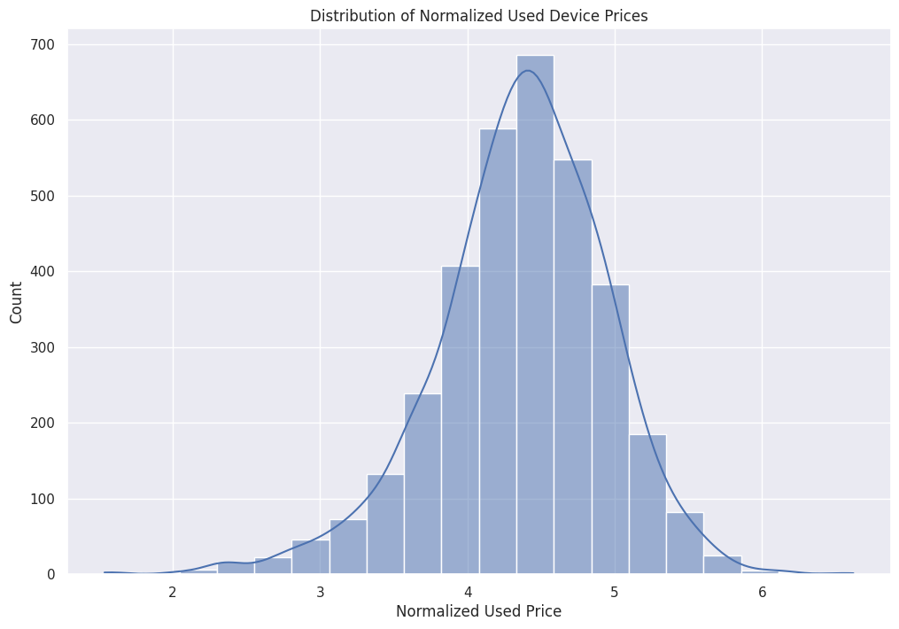

```python
plt.figure(figsize=(12,8))
sns.histplot(df['normalized_used_price'], bins=20, kde=True)
plt.title('Distribution of Normalized Used Device Prices')
plt.xlabel('Normalized Used Price')
plt.show()
```

### Percentage of the used device market that is dominated by android devices:

```python
df['os'].unique()
```

```
array(['Android', 'Others', 'iOS', 'Windows'], dtype=object)
```

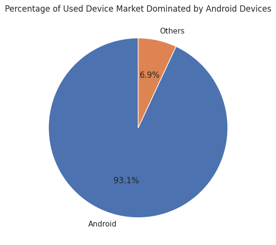

```python
android_share = df[df['os'] == 'Android'].shape[0] / df.shape[0]*100
labels = ['Android', 'Others']
sizes = [android_share, 100 - android_share]

plt.figure(figsize=(10,6))
plt.pie(sizes, labels=labels, autopct='%1.1f%%', startangle=90)
plt.title('Percentage of Used Device Market Dominated by Android Devices')
plt.show()
```

### Variation of RAM across different brands:

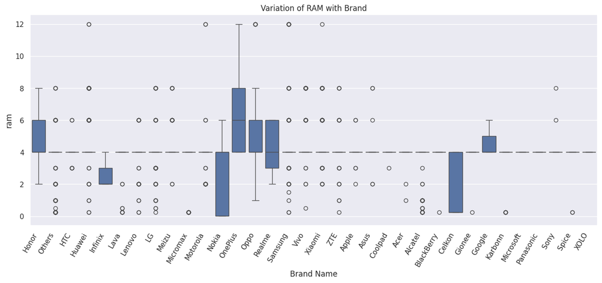

```python
plt.figure(figsize=(16,6))
sns.boxplot(x='brand_name', y='ram', data=df)
plt.title('Variation of RAM with Brand')
plt.xlabel('Brand Name')
plt.xticks(rotation=60, ha='right')
plt.show()
```

### Variation of weight for phones and tablets offering large batteries:

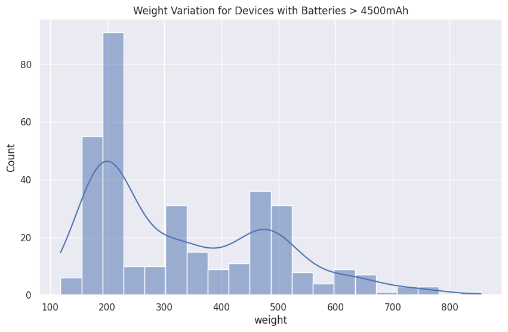

```python
lrg_batts = df[df['battery']>4500]
plt.figure(figsize=(10,6))
sns.histplot(lrg_batts['weight'], bins=20, kde=True)
plt.title('Weight Variation for Devices with Batteries > 4500mAh')
plt.show()
```

[figure not shown]

```python
plt.figure(figsize=(12,8))
sns.boxplot(x='screen_size', y='brand_name', data=df[df['screen_size']>6])
plt.title('Devices with Screen Size > 6in.')
plt.xticks(rotation=90)
plt.xlabel('Screen Size (inches)')
plt.ylabel('Brand Name')
plt.show()
```

### Distribution of devices offering selfie cameras greater than 8MP across different brands:

[figure not shown]

```python
plt.figure(figsize=(10,6))
sns.barplot(x='brand_name', y='selfie_camera_mp', data=df[df['selfie_camera_mp'] >8], estimator=sum)
plt.title('Devices with Selfie Cameras > 8MP Across Different Brands')
plt.xticks(rotation=60)
plt.xlabel('Brand Name')
plt.ylabel('Devices with Selfie Cameras > 8MP')
plt.show()
```

### Attributes that are highly correlated with the normalized price of a used device:

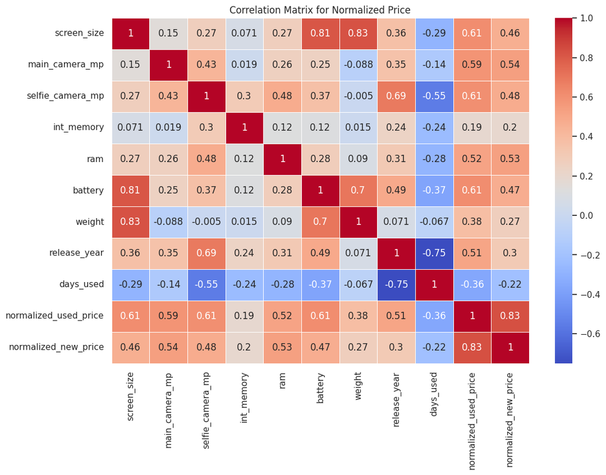

```python
plt.figure(figsize=(12,8))
sns.heatmap(df.corr(), annot=True, cmap='coolwarm', linewidth=.5)
plt.title('Correlation Matrix for Normalized Price')
plt.show()
```

### Count of devices released each year:

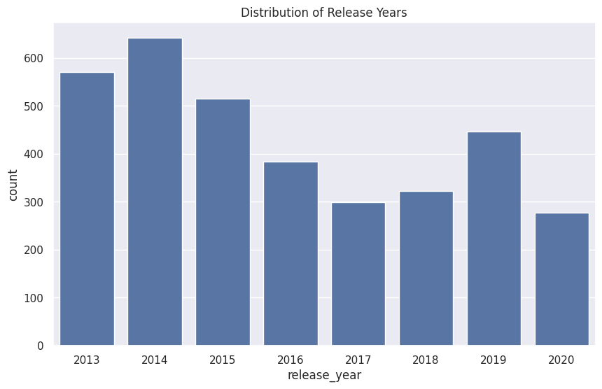

```python
plt.figure(figsize=(10,6))
sns.countplot(x='release_year', data=df)
plt.title('Distribution of Release Years')
plt.show()
```

### Correlation between 5G capable devices and normalized used price:

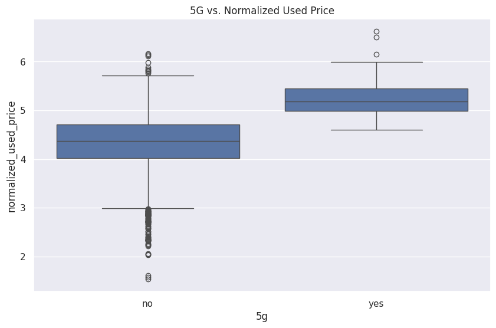

```python
plt.figure(figsize=(10,6))
sns.boxplot(data=df, x='5g', y='normalized_used_price')
plt.title('5G vs. Normalized Used Price')
plt.show()
```

### Normalized used prices of devices across different brands:

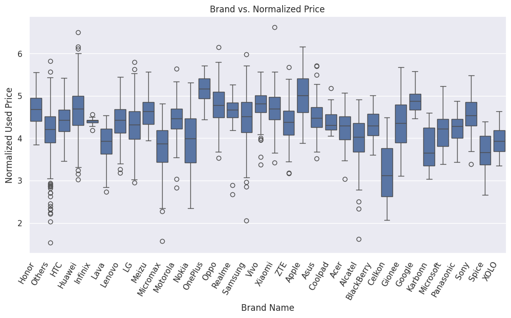

```python
plt.figure(figsize=(12,6))
sns.boxplot(data=df, x='brand_name', y='normalized_used_price')
plt.title('Brand vs. Normalized Price')
plt.xticks(rotation=60, ha='right')
plt.xlabel('Brand Name')
plt.ylabel('Normalized Used Price')
plt.show()
```

## Data Preprocessing

- Missing value treatment
- Feature engineering (if needed)
- Outlier detection and treatment (if needed)
- Preparing data for modeling
- Any other preprocessing steps (if needed)

##### **Missing value treatment: Creating a copy of the data and replacing the missing values with the median values of their respective columns**

```python
df2=df.copy()
```

```python
df2.isnull().sum()
```

```
brand_name                 0
os                         0
screen_size                0
4g                         0
5g                         0
main_camera_mp           179
selfie_camera_mp           2
int_memory                 4
ram                        4
battery                    6
weight                     7
release_year               0
days_used                  0
normalized_used_price      0
normalized_new_price       0
dtype: int64
```

```python
df2.median()
```

```
screen_size                12.830000
main_camera_mp              8.000000
selfie_camera_mp            5.000000
int_memory                 32.000000
ram                         4.000000
battery                  3000.000000
weight                    160.000000
release_year             2015.500000
days_used                 690.500000
normalized_used_price       4.405133
normalized_new_price        5.245892
dtype: float64
```

```python
df2=df2.fillna(df2.median())
```

```python
new_missing = df2.isnull().sum()
print(new_missing)
```

```
brand_name               0
os                       0
screen_size              0
4g                       0
5g                       0
main_camera_mp           0
selfie_camera_mp         0
int_memory               0
ram                      0
battery                  0
weight                   0
release_year             0
days_used                0
normalized_used_price    0
normalized_new_price     0
dtype: int64
```

##### **Feature engineering: creating a column of the age of each device with respect to the year 2021, when the data was collected.**

```python
df2["device_age"] = 2021 - df2["release_year"]
df2["device_age"].describe()
```

```
count    3454.000000
mean        5.034742
std         2.298455
min         1.000000
25%         3.000000
50%         5.500000
75%         7.000000
max         8.000000
Name: device_age, dtype: float64
```

```python
df2["device_age"]
```

```
0       1
1       1
2       1
3       1
4       1
       ..
3449    2
3450    3
3451    1
3452    1
3453    1
Name: device_age, Length: 3454, dtype: int64
```

##### **One-hot encoding: encoding the categorical variables in the os, 4g, and 5g columns to prepare them for possible analysis that could be made with that data**

```python
df2_encoded = pd.get_dummies(df2, drop_first=True)
df2_encoded
```

|  | screen_size | main_camera_mp | selfie_camera_mp | int_memory | ram | battery | weight | release_year | days_used | normalized_used_price | ... | brand_name_Spice | brand_name_Vivo | brand_name_XOLO | brand_name_Xiaomi | brand_name_ZTE | os_Others | os_Windows | os_iOS | 4g_yes | 5g_yes |
| --- | --- | --- | --- | --- | --- | --- | --- | --- | --- | --- | --- | --- | --- | --- | --- | --- | --- | --- | --- | --- | --- |
| 0 | 14.50 | 13.0 | 5.0 | 64.0 | 3.0 | 3020.0 | 146.0 | 2020 | 127 | 4.307572 | ... | 0 | 0 | 0 | 0 | 0 | 0 | 0 | 0 | 1 | 0 |
| 1 | 17.30 | 13.0 | 16.0 | 128.0 | 8.0 | 4300.0 | 213.0 | 2020 | 325 | 5.162097 | ... | 0 | 0 | 0 | 0 | 0 | 0 | 0 | 0 | 1 | 1 |
| 2 | 16.69 | 13.0 | 8.0 | 128.0 | 8.0 | 4200.0 | 213.0 | 2020 | 162 | 5.111084 | ... | 0 | 0 | 0 | 0 | 0 | 0 | 0 | 0 | 1 | 1 |
| 3 | 25.50 | 13.0 | 8.0 | 64.0 | 6.0 | 7250.0 | 480.0 | 2020 | 345 | 5.135387 | ... | 0 | 0 | 0 | 0 | 0 | 0 | 0 | 0 | 1 | 1 |
| 4 | 15.32 | 13.0 | 8.0 | 64.0 | 3.0 | 5000.0 | 185.0 | 2020 | 293 | 4.389995 | ... | 0 | 0 | 0 | 0 | 0 | 0 | 0 | 0 | 1 | 0 |
| ... | ... | ... | ... | ... | ... | ... | ... | ... | ... | ... | ... | ... | ... | ... | ... | ... | ... | ... | ... | ... | ... |
| 3449 | 15.34 | 8.0 | 8.0 | 64.0 | 6.0 | 5000.0 | 190.0 | 2019 | 232 | 4.492337 | ... | 0 | 0 | 0 | 0 | 0 | 0 | 0 | 0 | 1 | 0 |
| 3450 | 15.24 | 13.0 | 8.0 | 128.0 | 8.0 | 4000.0 | 200.0 | 2018 | 541 | 5.037732 | ... | 0 | 0 | 0 | 0 | 0 | 0 | 0 | 0 | 1 | 0 |
| 3451 | 15.80 | 13.0 | 5.0 | 32.0 | 3.0 | 4000.0 | 165.0 | 2020 | 201 | 4.357350 | ... | 0 | 0 | 0 | 0 | 0 | 0 | 0 | 0 | 1 | 0 |
| 3452 | 15.80 | 13.0 | 5.0 | 32.0 | 2.0 | 4000.0 | 160.0 | 2020 | 149 | 4.349762 | ... | 0 | 0 | 0 | 0 | 0 | 0 | 0 | 0 | 1 | 0 |
| 3453 | 12.83 | 13.0 | 5.0 | 16.0 | 2.0 | 4000.0 | 168.0 | 2020 | 176 | 4.132122 | ... | 0 | 0 | 0 | 0 | 0 | 0 | 0 | 0 | 1 | 0 |

3454 rows × 50 columns

```python
Apple_devices = df2_encoded[df2_encoded['os_iOS']==1]
Apple_devices
```

|  | screen_size | main_camera_mp | selfie_camera_mp | int_memory | ram | battery | weight | release_year | days_used | normalized_used_price | ... | brand_name_Spice | brand_name_Vivo | brand_name_XOLO | brand_name_Xiaomi | brand_name_ZTE | os_Others | os_Windows | os_iOS | 4g_yes | 5g_yes |
| --- | --- | --- | --- | --- | --- | --- | --- | --- | --- | --- | --- | --- | --- | --- | --- | --- | --- | --- | --- | --- | --- |
| 391 | 27.94 | 12.0 | 7.0 | 64.0 | 4.0 | 7812.0 | 468.0 | 2018 | 601 | 5.359836 | ... | 0 | 0 | 0 | 0 | 0 | 0 | 0 | 1 | 1 | 0 |
| 392 | 18.01 | 8.0 | 1.2 | 16.0 | 2.0 | 5124.0 | 299.0 | 2015 | 827 | 4.562680 | ... | 0 | 0 | 0 | 0 | 0 | 0 | 0 | 1 | 1 | 0 |
| 642 | 25.53 | 8.0 | 7.0 | 64.0 | 4.0 | 3969.0 | 456.0 | 2019 | 496 | 4.937061 | ... | 0 | 0 | 0 | 0 | 0 | 0 | 0 | 1 | 1 | 0 |
| 643 | 18.01 | 8.0 | 7.0 | 64.0 | 4.0 | 5124.0 | 300.5 | 2019 | 250 | 4.794633 | ... | 0 | 0 | 0 | 0 | 0 | 0 | 0 | 1 | 1 | 0 |
| 644 | 30.71 | 12.0 | 7.0 | 1024.0 | 4.0 | 9720.0 | 631.0 | 2018 | 543 | 5.808022 | ... | 0 | 0 | 0 | 0 | 0 | 0 | 0 | 1 | 1 | 0 |
| 645 | 27.94 | 12.0 | 7.0 | 1024.0 | 4.0 | 7812.0 | 468.0 | 2018 | 525 | 6.158969 | ... | 0 | 0 | 0 | 0 | 0 | 0 | 0 | 1 | 1 | 0 |
| 646 | 15.37 | 12.0 | 7.0 | 64.0 | 4.0 | 3174.0 | 208.0 | 2018 | 583 | 5.570594 | ... | 0 | 0 | 0 | 0 | 0 | 0 | 0 | 1 | 1 | 0 |
| 647 | 12.90 | 12.0 | 7.0 | 64.0 | 4.0 | 2658.0 | 177.0 | 2018 | 641 | 5.583459 | ... | 0 | 0 | 0 | 0 | 0 | 0 | 0 | 1 | 1 | 0 |
| 648 | 15.27 | 12.0 | 7.0 | 64.0 | 4.0 | 2942.0 | 194.0 | 2018 | 673 | 5.492650 | ... | 0 | 0 | 0 | 0 | 0 | 0 | 0 | 1 | 1 | 0 |
| 649 | 23.04 | 8.0 | 1.2 | 32.0 | 4.0 | 5493.0 | 469.0 | 2018 | 673 | 4.923478 | ... | 0 | 0 | 0 | 0 | 0 | 0 | 0 | 1 | 1 | 0 |
| 650 | 12.90 | 12.0 | 7.0 | 64.0 | 4.0 | 2716.0 | 174.0 | 2017 | 629 | 4.522115 | ... | 0 | 0 | 0 | 0 | 0 | 0 | 0 | 1 | 1 | 0 |
| 651 | 12.83 | 12.0 | 7.0 | 64.0 | 4.0 | 2691.0 | 202.0 | 2017 | 815 | 5.175415 | ... | 0 | 0 | 0 | 0 | 0 | 0 | 0 | 1 | 1 | 0 |
| 652 | 10.34 | 12.0 | 7.0 | 64.0 | 4.0 | 1821.0 | 148.0 | 2017 | 604 | 5.120685 | ... | 0 | 0 | 0 | 0 | 0 | 0 | 0 | 1 | 1 | 0 |
| 653 | 30.71 | 12.0 | 7.0 | 64.0 | 4.0 | 2256.0 | 677.0 | 2017 | 541 | 5.759186 | ... | 0 | 0 | 0 | 0 | 0 | 0 | 0 | 1 | 1 | 0 |
| 654 | 25.53 | 12.0 | 7.0 | 64.0 | 4.0 | 8134.0 | 469.0 | 2017 | 629 | 5.290789 | ... | 0 | 0 | 0 | 0 | 0 | 0 | 0 | 1 | 1 | 0 |
| 655 | 23.04 | 8.0 | 1.2 | 32.0 | 4.0 | 8827.0 | 469.0 | 2017 | 578 | 4.669459 | ... | 0 | 0 | 0 | 0 | 0 | 0 | 0 | 1 | 1 | 0 |
| 656 | 12.83 | 12.0 | 7.0 | 32.0 | 4.0 | 2900.0 | 188.0 | 2016 | 833 | 4.750568 | ... | 0 | 0 | 0 | 0 | 0 | 0 | 0 | 1 | 1 | 0 |
| 657 | 10.34 | 12.0 | 7.0 | 32.0 | 4.0 | 1960.0 | 138.0 | 2016 | 1026 | 4.681112 | ... | 0 | 0 | 0 | 0 | 0 | 0 | 0 | 1 | 1 | 0 |
| 658 | 23.04 | 12.0 | 5.0 | 32.0 | 4.0 | 7306.0 | 437.0 | 2016 | 704 | 5.373471 | ... | 0 | 0 | 0 | 0 | 0 | 0 | 0 | 1 | 1 | 0 |
| 659 | 10.16 | 12.0 | 1.2 | 16.0 | 4.0 | 1624.0 | 113.0 | 2016 | 894 | 4.437461 | ... | 0 | 0 | 0 | 0 | 0 | 0 | 0 | 1 | 1 | 0 |
| 660 | 12.83 | 12.0 | 5.0 | 16.0 | 4.0 | 2750.0 | 192.0 | 2015 | 667 | 4.633077 | ... | 0 | 0 | 0 | 0 | 0 | 0 | 0 | 1 | 1 | 0 |
| 661 | 10.34 | 12.0 | 5.0 | 16.0 | 4.0 | 1715.0 | 143.0 | 2015 | 778 | 5.170370 | ... | 0 | 0 | 0 | 0 | 0 | 0 | 0 | 1 | 1 | 0 |
| 662 | 30.71 | 8.0 | 1.2 | 32.0 | 4.0 | 3937.0 | 713.0 | 2015 | 572 | 5.558872 | ... | 0 | 0 | 0 | 0 | 0 | 0 | 0 | 1 | 1 | 0 |
| 663 | 18.01 | 8.0 | 1.2 | 16.0 | 4.0 | 5124.0 | 299.0 | 2015 | 547 | 4.463146 | ... | 0 | 0 | 0 | 0 | 0 | 0 | 0 | 1 | 1 | 0 |
| 664 | 23.04 | 8.0 | 1.2 | 16.0 | 4.0 | 7340.0 | 437.0 | 2014 | 914 | 4.591984 | ... | 0 | 0 | 0 | 0 | 0 | 0 | 0 | 1 | 1 | 0 |
| 665 | 18.01 | 5.0 | 1.2 | 16.0 | 4.0 | 6470.0 | 331.0 | 2014 | 719 | 4.372986 | ... | 0 | 0 | 0 | 0 | 0 | 0 | 0 | 1 | 1 | 0 |
| 666 | 12.83 | 8.0 | 1.2 | 16.0 | 4.0 | 2915.0 | 172.0 | 2014 | 1082 | 4.251776 | ... | 0 | 0 | 0 | 0 | 0 | 0 | 0 | 1 | 1 | 0 |
| 667 | 10.34 | 8.0 | 1.2 | 16.0 | 4.0 | 1810.0 | 129.0 | 2014 | 877 | 3.930648 | ... | 0 | 0 | 0 | 0 | 0 | 0 | 0 | 1 | 1 | 0 |
| 668 | 23.04 | 5.0 | 1.2 | 16.0 | 4.0 | 8600.0 | 469.0 | 2013 | 995 | 4.628398 | ... | 0 | 0 | 0 | 0 | 0 | 0 | 0 | 1 | 1 | 0 |
| 669 | 18.01 | 5.0 | 1.2 | 16.0 | 4.0 | 6470.0 | 331.0 | 2013 | 945 | 4.422088 | ... | 0 | 0 | 0 | 0 | 0 | 0 | 0 | 1 | 1 | 0 |
| 670 | 10.16 | 8.0 | 1.2 | 16.0 | 4.0 | 1560.0 | 112.0 | 2013 | 1070 | 3.879706 | ... | 0 | 0 | 0 | 0 | 0 | 0 | 0 | 1 | 1 | 0 |
| 671 | 10.16 | 8.0 | 1.2 | 32.0 | 4.0 | 1510.0 | 132.0 | 2013 | 712 | 4.666359 | ... | 0 | 0 | 0 | 0 | 0 | 0 | 0 | 1 | 1 | 0 |
| 3444 | 10.34 | 12.0 | 7.0 | 64.0 | 3.0 | 1821.0 | 148.0 | 2020 | 235 | 5.011901 | ... | 0 | 0 | 0 | 0 | 0 | 0 | 0 | 1 | 1 | 0 |
| 3445 | 15.37 | 8.0 | 7.0 | 64.0 | 4.0 | 3969.0 | 226.0 | 2019 | 298 | 5.340466 | ... | 0 | 0 | 0 | 0 | 0 | 0 | 0 | 1 | 1 | 0 |
| 3446 | 12.90 | 8.0 | 7.0 | 64.0 | 4.0 | 3046.0 | 188.0 | 2019 | 351 | 5.440164 | ... | 0 | 0 | 0 | 0 | 0 | 0 | 0 | 1 | 1 | 0 |
| 3447 | 15.27 | 8.0 | 7.0 | 64.0 | 4.0 | 3110.0 | 194.0 | 2019 | 208 | 5.100902 | ... | 0 | 0 | 0 | 0 | 0 | 0 | 0 | 1 | 1 | 0 |

36 rows × 50 columns

##### **Outlier Check: checking for any outliers in the data using boxplots**

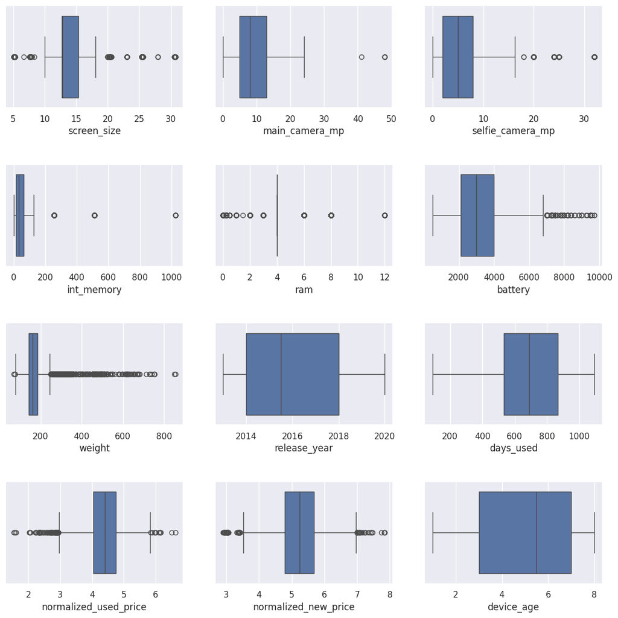

```python
numerical_columns = df2.select_dtypes(include=['float64', 'int64']).columns

plt.figure(figsize=(12,12))

for i, column in enumerate(numerical_columns):
  plt.subplot(4, 3, i+1)
  sns.boxplot(data=df2, x=column)
  plt.tight_layout(pad=3)

plt.show()
```

##### **Preparing the data for modeling**

```python
X = df2_encoded.drop('normalized_used_price', axis=1)
y = df2_encoded['normalized_used_price']

X_train, X_test, y_train, y_test = train_test_split(X,y, test_size=0.2, random_state=42)
```

```python
X_train.shape[0]
```

```
2763
```

```python
X_test.shape[0]
```

```
691
```

## EDA

- It is a good idea to explore the data once again after manipulating it.

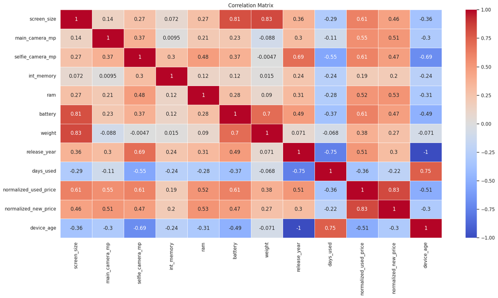

```python
plt.figure(figsize=(18,10))
sns.heatmap(df2.corr(), annot=True, cmap='coolwarm', linewidth=.5)
plt.title("Correlation Matrix")
plt.tight_layout()
plt.show()
```

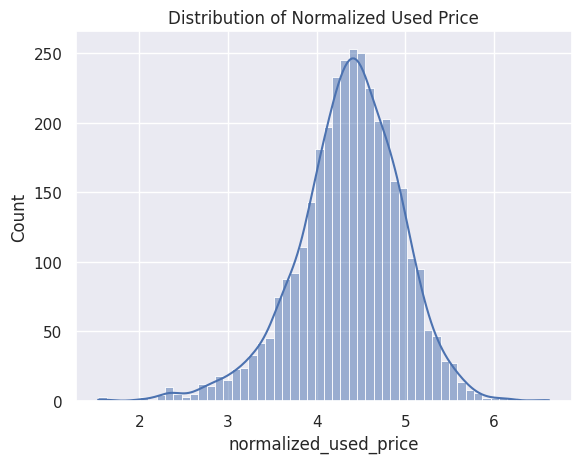

```python
sns.histplot(df2_encoded['normalized_used_price'], kde=True)
plt.title("Distribution of Normalized Used Price")
plt.show()
```

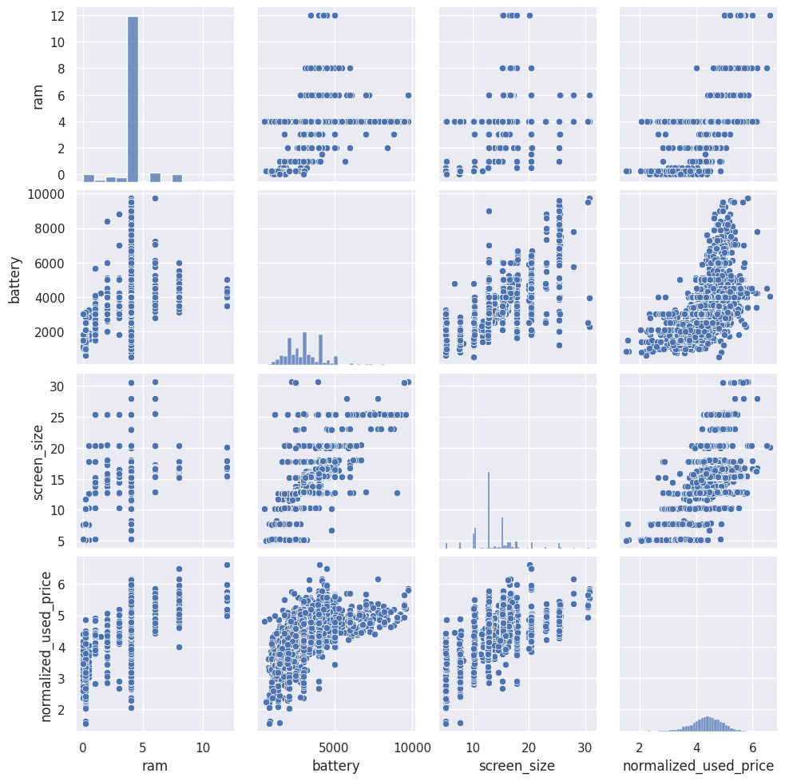

```python
sns.pairplot(df2_encoded, vars=['ram', 'battery', 'screen_size', 'normalized_used_price'])
plt.show()
```

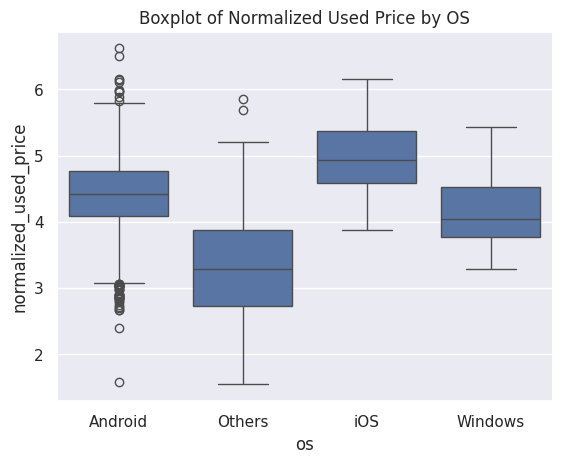

```python
sns.boxplot(x='os', y='normalized_used_price', data=df2)
plt.title("Boxplot of Normalized Used Price by OS")
plt.show()
```

## Model Building - Linear Regression

```python
from sklearn.linear_model import LinearRegression

model = LinearRegression()
model.fit(X_train, y_train)
```

```
LinearRegression()
```

```python
y_pred = model.predict(X_test)
```

## Model Performance Check

```python
from sklearn.metrics import mean_squared_error, mean_absolute_error, r2_score

def reg_metrics(y_true, y_pred, num_features):
    mse = mean_squared_error(y_true, y_pred)
    rmse = np.sqrt(mse)
    mae = mean_absolute_error(y_true, y_pred)
    r2 = r2_score(y_true, y_pred)

    mape = np.mean(np.abs((y_true - y_pred) / y_true)) * 100

    n = len(y_true)
    adj_r2 = 1 - ((1 - r2) * (n - 1) / (n - num_features - 1))

    print(f'Mean Squared Error (MSE): {mse}')
    print(f'Root Mean Squared Error (RMSE): {rmse}')
    print(f'Mean Absolute Error (MAE): {mae}')
    print(f'R-squared (R2): {r2}')
    print(f'Mean Absolute Percentage Error (MAPE): {mape}%')
    print(f'Adjusted R-squared: {adj_r2}')

reg_metrics(y_test, y_pred, num_features=len(X.columns))
```

```
Mean Squared Error (MSE): 0.05330904376614576
Root Mean Squared Error (RMSE): 0.23088751323132603
Mean Absolute Error (MAE): 0.1843799983937714
R-squared (R2): 0.8357287938412603
Mean Absolute Percentage Error (MAPE): 4.343808574867378%
Adjusted R-squared: 0.8231714005467545
```

```python
y_train_pred = model.predict(X_train)

train_rmse = np.sqrt(mean_squared_error(y_train, y_train_pred))
train_mae = mean_absolute_error(y_train, y_train_pred)
train_r2 = r2_score(y_train, y_train_pred)

print("Training Set Performance:")
print(f"RMSE: {train_rmse}")
print(f"MAE: {train_mae}")
print(f"R^2: {train_r2}")
```

```
Training Set Performance:
RMSE: 0.232100049509796
MAE: 0.1800334444175621
R^2: 0.8470525470879774
```

```python
y_test_pred = model.predict(X_test)
test_rmse = np.sqrt(mean_squared_error(y_test, y_test_pred))
test_mae = mean_absolute_error(y_test, y_test_pred)
test_r2 = r2_score(y_test, y_test_pred)

print("Test Set Performance:")
print(f"RMSE: {test_rmse}")
print(f"MAE: {test_mae}")
print(f"R^2: {test_r2}")
```

```
Test Set Performance:
RMSE: 0.23088751323132603
MAE: 0.1843799983937714
R^2: 0.8357287938412603
```

## Checking Linear Regression Assumptions

- In order to make statistical inferences from a linear regression model, it is important to ensure that the assumptions of linear regression are satisfied.

##### **Checking for multicollinearity and removing any multicollinearity**

```python
vif_data = pd.DataFrame()
vif_data["Variable"]=X.columns
vif_data["VIF"] = [variance_inflation_factor(X.values, i) for i in range(X.shape[1])]

vif_data
```

|  | Variable | VIF |
| --- | --- | --- |
| 0 | screen_size | 7.234351 |
| 1 | main_camera_mp | 2.140280 |
| 2 | selfie_camera_mp | 2.854270 |
| 3 | int_memory | 1.296283 |
| 4 | ram | 2.253951 |
| 5 | battery | 4.187970 |
| 6 | weight | 5.774759 |
| 7 | release_year | 217.483502 |
| 8 | days_used | 2.584249 |
| 9 | normalized_new_price | 3.109070 |
| 10 | device_age | 28.286469 |
| 11 | brand_name_Alcatel | 3.297840 |
| 12 | brand_name_Apple | 14.633682 |
| 13 | brand_name_Asus | 3.318998 |
| 14 | brand_name_BlackBerry | 1.520442 |
| 15 | brand_name_Celkon | 1.775953 |
| 16 | brand_name_Coolpad | 1.450367 |
| 17 | brand_name_Gionee | 2.105170 |
| 18 | brand_name_Google | 1.329088 |
| 19 | brand_name_HTC | 3.137338 |
| 20 | brand_name_Honor | 3.348964 |
| 21 | brand_name_Huawei | 5.710494 |
| 22 | brand_name_Infinix | 1.238327 |
| 23 | brand_name_Karbonn | 1.585234 |
| 24 | brand_name_LG | 4.791420 |
| 25 | brand_name_Lava | 1.724480 |
| 26 | brand_name_Lenovo | 4.201020 |
| 27 | brand_name_Meizu | 2.259176 |
| 28 | brand_name_Micromax | 3.249404 |
| 29 | brand_name_Microsoft | 1.951270 |
| 30 | brand_name_Motorola | 3.125100 |
| 31 | brand_name_Nokia | 3.347520 |
| 32 | brand_name_OnePlus | 1.488357 |
| 33 | brand_name_Oppo | 3.614472 |
| 34 | brand_name_Others | 9.378308 |
| 35 | brand_name_Panasonic | 1.929057 |
| 36 | brand_name_Realme | 1.894893 |
| 37 | brand_name_Samsung | 7.104747 |
| 38 | brand_name_Sony | 2.719327 |
| 39 | brand_name_Spice | 1.604603 |
| 40 | brand_name_Vivo | 3.377822 |
| 41 | brand_name_XOLO | 1.956823 |
| 42 | brand_name_Xiaomi | 3.650772 |
| 43 | brand_name_ZTE | 3.714406 |
| 44 | os_Others | 1.758533 |
| 45 | os_Windows | 1.702321 |
| 46 | os_iOS | 13.636850 |
| 47 | 4g_yes | 2.501450 |
| 48 | 5g_yes | 1.847536 |

```python
def remove_multicollinearity(predictors, threshold=5):
    while True:
        vif_data = pd.DataFrame({'Variable': predictors.columns, 'VIF': [variance_inflation_factor(predictors.values, i) for i in range(predictors.shape[1])]})

        high_vif_vars = vif_data.loc[vif_data['VIF'] > threshold, 'Variable'].tolist()

        if not high_vif_vars:
            print("No more variables with VIF exceeding the threshold.")
            break

        print(f"Removing variables {high_vif_vars} with VIF exceeding the threshold.")
        predictors = predictors.drop(high_vif_vars, axis=1)

    return predictors

X_train, X_test, y_train, y_test = train_test_split(X, y, test_size=0.2, random_state=42)

X_train_no_multico = remove_multicollinearity(X_train)
```

```
Removing variables ['screen_size', 'weight', 'release_year', 'device_age', 'brand_name_Apple', 'brand_name_Huawei', 'brand_name_LG', 'brand_name_Others', 'brand_name_Samsung', 'os_iOS'] with VIF exceeding the threshold.
Removing variables ['main_camera_mp', 'ram', 'battery', 'days_used', 'normalized_new_price', '4g_yes'] with VIF exceeding the threshold.
No more variables with VIF exceeding the threshold.
```

```python
vif_data
```

|  | Variable | VIF |
| --- | --- | --- |
| 0 | screen_size | 7.234351 |
| 1 | main_camera_mp | 2.140280 |
| 2 | selfie_camera_mp | 2.854270 |
| 3 | int_memory | 1.296283 |
| 4 | ram | 2.253951 |
| 5 | battery | 4.187970 |
| 6 | weight | 5.774759 |
| 7 | release_year | 217.483502 |
| 8 | days_used | 2.584249 |
| 9 | normalized_new_price | 3.109070 |
| 10 | device_age | 28.286469 |
| 11 | brand_name_Alcatel | 3.297840 |
| 12 | brand_name_Apple | 14.633682 |
| 13 | brand_name_Asus | 3.318998 |
| 14 | brand_name_BlackBerry | 1.520442 |
| 15 | brand_name_Celkon | 1.775953 |
| 16 | brand_name_Coolpad | 1.450367 |
| 17 | brand_name_Gionee | 2.105170 |
| 18 | brand_name_Google | 1.329088 |
| 19 | brand_name_HTC | 3.137338 |
| 20 | brand_name_Honor | 3.348964 |
| 21 | brand_name_Huawei | 5.710494 |
| 22 | brand_name_Infinix | 1.238327 |
| 23 | brand_name_Karbonn | 1.585234 |
| 24 | brand_name_LG | 4.791420 |
| 25 | brand_name_Lava | 1.724480 |
| 26 | brand_name_Lenovo | 4.201020 |
| 27 | brand_name_Meizu | 2.259176 |
| 28 | brand_name_Micromax | 3.249404 |
| 29 | brand_name_Microsoft | 1.951270 |
| 30 | brand_name_Motorola | 3.125100 |
| 31 | brand_name_Nokia | 3.347520 |
| 32 | brand_name_OnePlus | 1.488357 |
| 33 | brand_name_Oppo | 3.614472 |
| 34 | brand_name_Others | 9.378308 |
| 35 | brand_name_Panasonic | 1.929057 |
| 36 | brand_name_Realme | 1.894893 |
| 37 | brand_name_Samsung | 7.104747 |
| 38 | brand_name_Sony | 2.719327 |
| 39 | brand_name_Spice | 1.604603 |
| 40 | brand_name_Vivo | 3.377822 |
| 41 | brand_name_XOLO | 1.956823 |
| 42 | brand_name_Xiaomi | 3.650772 |
| 43 | brand_name_ZTE | 3.714406 |
| 44 | os_Others | 1.758533 |
| 45 | os_Windows | 1.702321 |
| 46 | os_iOS | 13.636850 |
| 47 | 4g_yes | 2.501450 |
| 48 | 5g_yes | 1.847536 |

##### **Checking for linearity of all the variables**

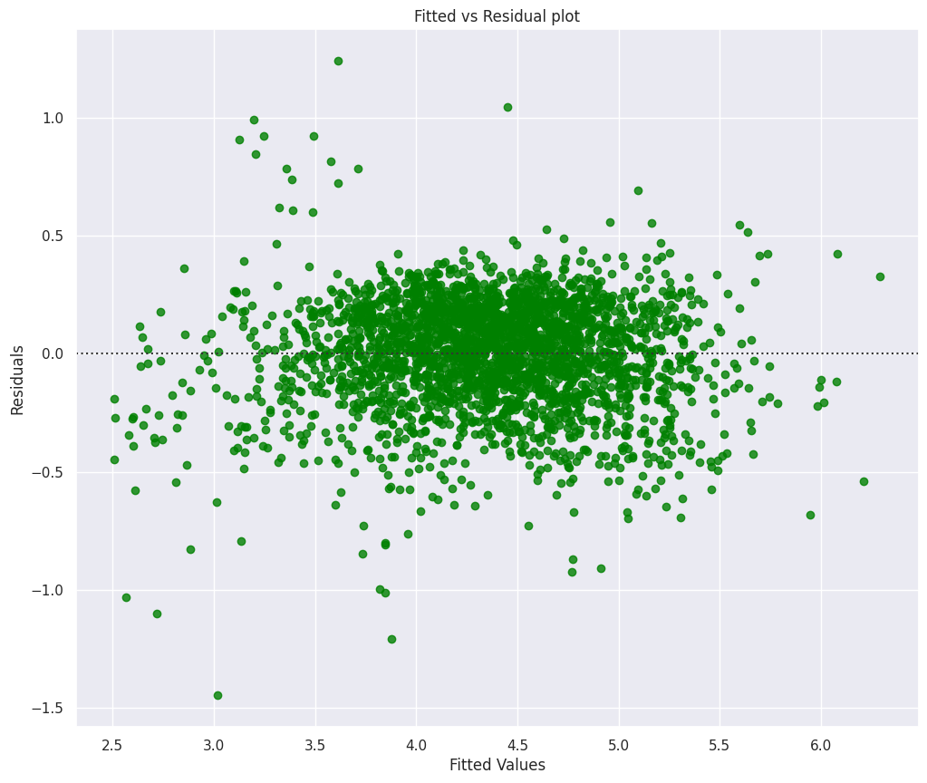

```python
df_pred = pd.DataFrame({"Actual Values": y_train, "Fitted Values": y_train_pred, "Residuals": y_train-y_train_pred})

plt.figure(figsize=(12,10))
sns.residplot(data=df_pred, x="Fitted Values", y="Residuals", color="green")
plt.xlabel("Fitted Values")
plt.ylabel("Residuals")
plt.title("Fitted vs Residual plot")
plt.show()
```

##### **Checking for normality of the residuals**

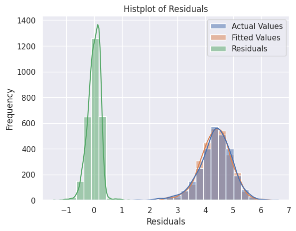

```python
sns.histplot(data=df_pred, bins=30, color="blue", kde=True)
plt.title("Histplot of Residuals")
plt.xlabel("Residuals")
plt.ylabel("Frequency")
plt.show()
```

##### **Checking for homoscedasticity**

```python
import statsmodels.stats.api as sms
from statsmodels.compat import lzip

values = ["F statistic", "p-value"]
test = sms.het_goldfeldquandt(y_train - y_train_pred, X_train)
lzip(values, test)
```

```
[('F statistic', 0.9351384241230407), ('p-value', 0.8894971498875547)]
```

## Final Model

```python
X_train = sm.add_constant(X_train)
olsmodel_final = sm.OLS(y_train, X_train).fit()

print(olsmodel_final.summary())
```

```
                              OLS Regression Results
=================================================================================
Dep. Variable:     normalized_used_price   R-squared:                       0.847
Model:                               OLS   Adj. R-squared:                  0.844
Method:                    Least Squares   F-statistic:                     313.1
Date:                   Sun, 11 Feb 2024   Prob (F-statistic):               0.00
Time:                           04:38:12   Log-Likelihood:                 115.07
No. Observations:                   2763   AIC:                            -132.1
Df Residuals:                       2714   BIC:                             158.1
Df Model:                             48
Covariance Type:               nonrobust
=========================================================================================
                            coef    std err          t      P>|t|      [0.025      0.975]
-----------------------------------------------------------------------------------------
const                 -1.246e-05   2.11e-06     -5.910      0.000   -1.66e-05   -8.33e-06
screen_size               0.0281      0.003      8.508      0.000       0.022       0.035
main_camera_mp            0.0213      0.001     15.347      0.000       0.019       0.024
selfie_camera_mp          0.0127      0.001     11.580      0.000       0.011       0.015
int_memory             9.163e-05   5.95e-05      1.541      0.123    -2.5e-05       0.000
ram                       0.0257      0.005      5.176      0.000       0.016       0.035
battery               -1.756e-05   7.05e-06     -2.490      0.013   -3.14e-05   -3.73e-06
weight                    0.0008      0.000      6.645      0.000       0.001       0.001
release_year              0.0007   3.36e-05     20.587      0.000       0.001       0.001
days_used              2.313e-05   2.87e-05      0.805      0.421   -3.32e-05    7.95e-05
normalized_new_price      0.4246      0.012     36.808      0.000       0.402       0.447
device_age               -0.0259      0.004     -6.065      0.000      -0.034      -0.018
brand_name_Alcatel       -0.0702      0.046     -1.526      0.127      -0.160       0.020
brand_name_Apple         -0.0075      0.147     -0.051      0.959      -0.296       0.281
brand_name_Asus           0.0120      0.045      0.263      0.792      -0.077       0.101
brand_name_BlackBerry     0.0230      0.069      0.333      0.739      -0.112       0.158
brand_name_Celkon        -0.1864      0.063     -2.977      0.003      -0.309      -0.064
brand_name_Coolpad        0.0079      0.066      0.121      0.904      -0.121       0.137
brand_name_Gionee        -0.0327      0.055     -0.599      0.549      -0.140       0.074
brand_name_Google        -0.0930      0.079     -1.178      0.239      -0.248       0.062
brand_name_HTC           -0.0236      0.046     -0.509      0.611      -0.115       0.067
brand_name_Honor         -0.0244      0.046     -0.526      0.599      -0.116       0.067
brand_name_Huawei        -0.0482      0.043     -1.132      0.258      -0.132       0.035
brand_name_Infinix        0.1079      0.098      1.098      0.272      -0.085       0.300
brand_name_Karbonn       -0.0474      0.062     -0.765      0.445      -0.169       0.074
brand_name_LG            -0.0556      0.043     -1.279      0.201      -0.141       0.030
```

[output cut: 20 more lines]

```
os_Windows               -0.0165      0.041     -0.399      0.690      -0.097       0.064
os_iOS                   -0.0832      0.147     -0.565      0.572      -0.372       0.205
4g_yes                    0.0375      0.015      2.496      0.013       0.008       0.067
5g_yes                   -0.0410      0.030     -1.363      0.173      -0.100       0.018
==============================================================================
Omnibus:                      262.571   Durbin-Watson:                   1.975
Prob(Omnibus):                  0.000   Jarque-Bera (JB):              696.882
Skew:                          -0.531   Prob(JB):                    4.72e-152
Kurtosis:                       5.219   Cond. No.                     2.85e+18
==============================================================================

Notes:
[1] Standard Errors assume that the covariance matrix of the errors is correctly specified.
[2] The smallest eigenvalue is 5.28e-27. This might indicate that there are
strong multicollinearity problems or that the design matrix is singular.
```

## Actionable Insights and Recommendations

-Looking at the R-squared, we can see that 84.7% of the variance in normalized_used_price is explained by our Linear Regression model

-Release Year coefficient shows that newer devices will have higher prices.

-As far as price goes for phones with different operating systems, the devices under os_Others tend to have lower prices than those running Android, Apple, or Windows.

-The Durbin-Watson value being 1.975 implies that there was no significant autocorrelation in the residuals.